# Spotify_Songs

Thibault Eudes

28/10/2021

La base données ‘Spotify Songs’ rescence les informations de 28356 titres, provenant de l’API de l’entreprise en fin janvier 2020. Les chansons possèdent un ensemble de informations sur leur provenance, artiste etc. mais également des colonnes de scoring sur différentes charactéristiques comme l’energie, l’accoustiquee et autres. Nous nous interesserons dans cette étude aux différentes caractéristiques qui permettent à une chanson d’être populaire.

# Importation et nettoyage des données

###1 Quelle est la durée moyenne des titres sur Spotify ?

```
## [1] 00:03:46
```

###2 Spotify a t-il une repartition équitable des genres de musique ?

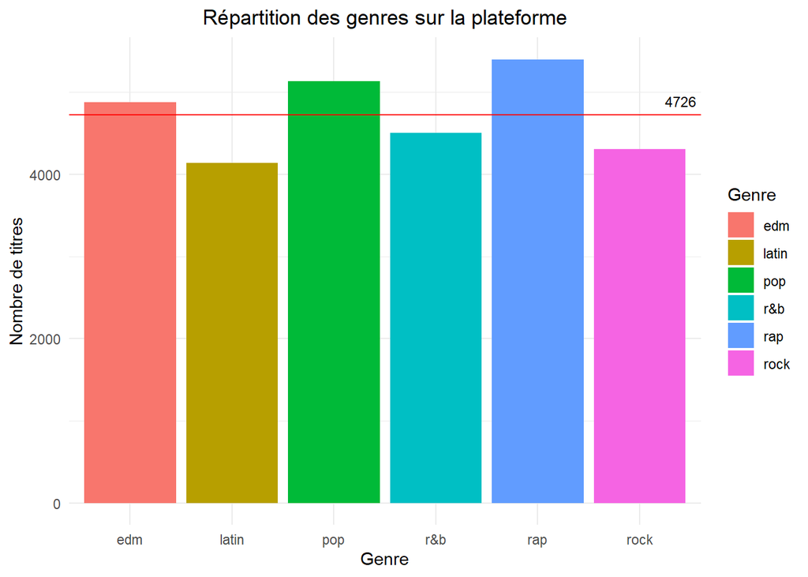

On observe une répartition plutot homogène des genres de musique.

###3 Y a t-il un genre predominant parmis les chansons les plus populaires ?

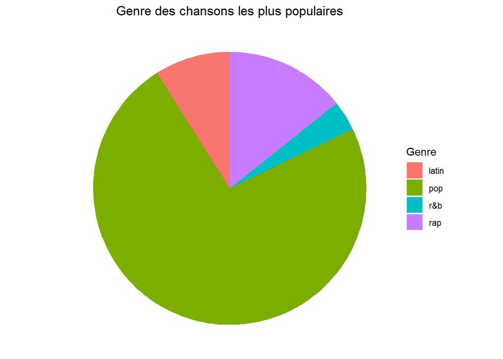

[output not shown]

###4 Cela se verifie t il sur l’echantillon global?

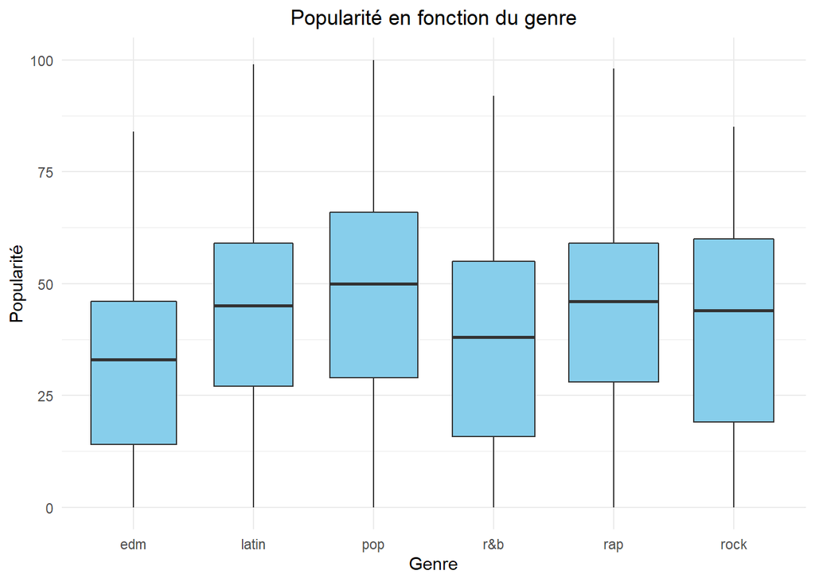

La pop domine en popularité pour l’ensemble du jeu de données. On peut également observer que l’edm et le rnb sont en moyenne moins écoutées.

###5 Les styles de musique sont-ils soumis aux mêmes contraintes de durée de chanson?

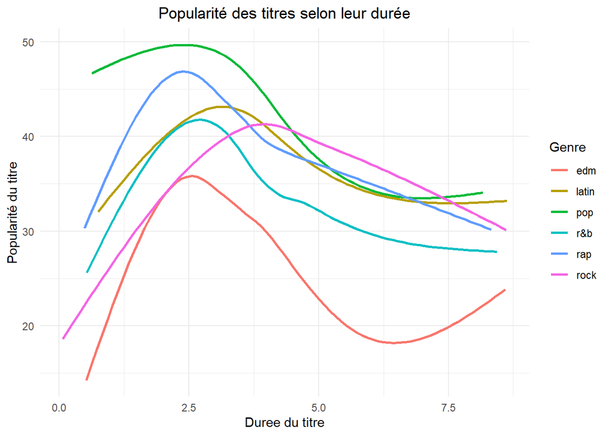

L’EDM se démarque et dépend un peu plus de la durée que les autres genres, mais la relation qu’ont les genres entre la durée du titre et sa popularité est plutot homogène. Il est preferable de faire une chanson entre 2 minutes 30 et 3 minutes 45.

###6 Les chansons suivent elles cette tendance (tous genres confondus)?

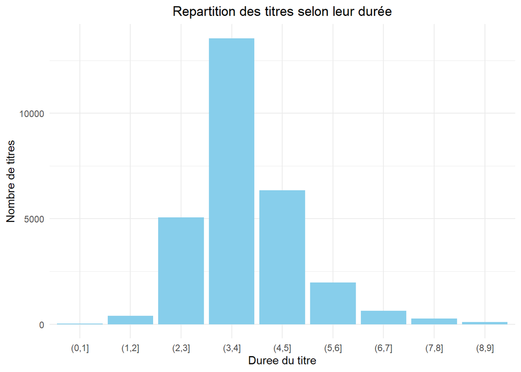

Les chansons entre 4 et 5 minutes sont surreprésentées par rapport aux attentes des consommateurs. Les chansons sont globalement en phase avec les choix d’écoute des utilisateurs de Spotify.

###7 Y a t-il une formule pour faire une chanson populaire ?

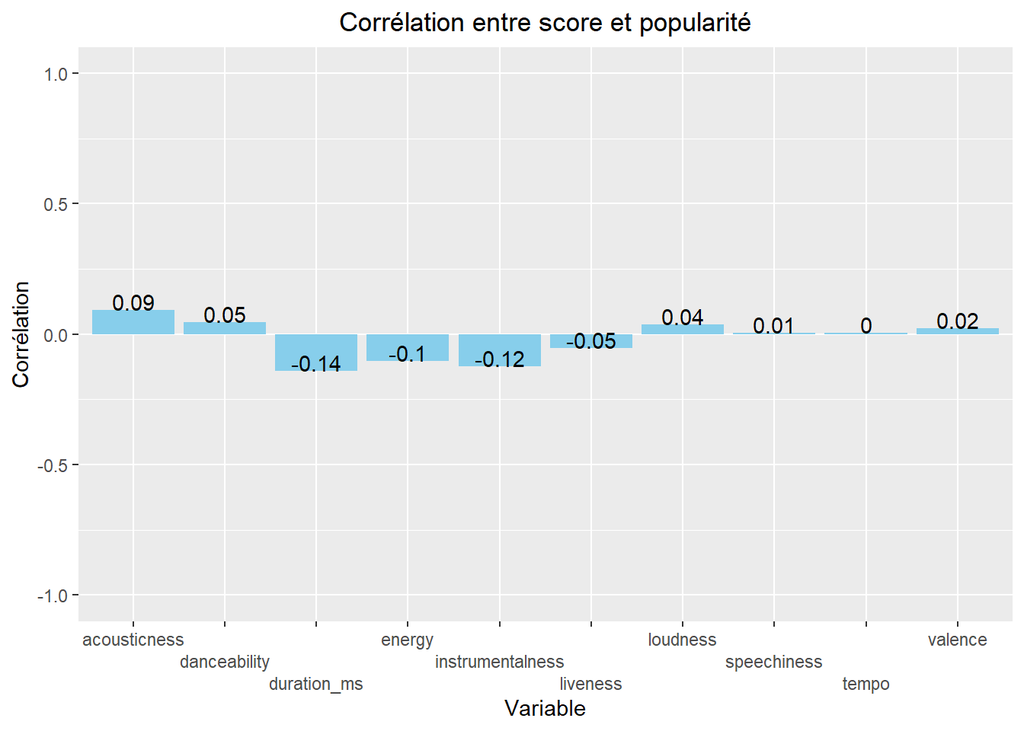

Les corrélations sont toutes plutot basses on peut donc supposer qu’il n’y a à priori pas de recette miracle. On peut retenir une très légère préférence pour les musiques avec des paroles ( cor_instrumentalness= -0.12 ), utilisant des instruments de musique (cor_accounsticness=0.09) et un rythme pas trop rapide (cor_energy=-0.1)

###8 La musique électronique est elle plus dépendante de certaines caractéristiques pour être populaire ?

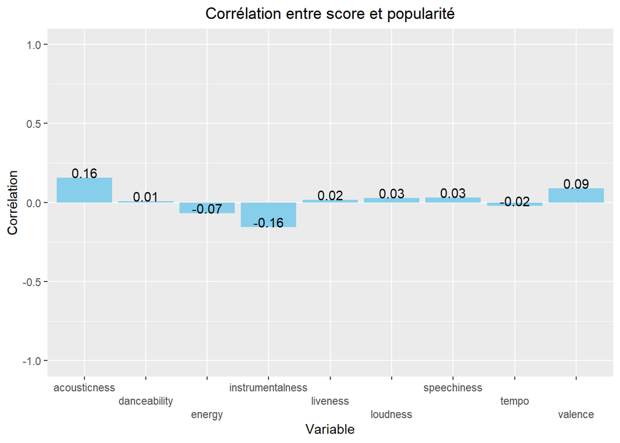

###9 Les chansons les plus populaires sont elles determinées par leur ancienneté?

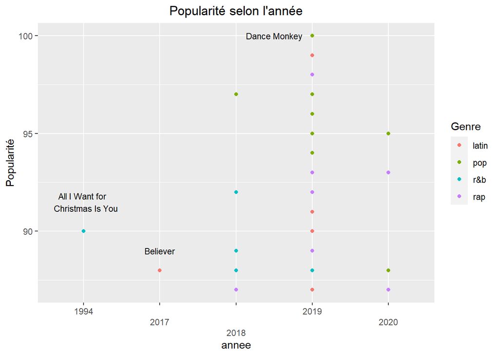

On constate que les chansons les plus populaires sont les plus récentes, avec seulement deux chansonsde 3 ans ou plus: “Believer” (2017), et “All I want for Christmas is You” (1994) dont la popularité est peut être expliquée par la date des données proche de la période de Noël. Il ny a pas d’edm dans les 100 chansons les plus populaires.

###10 Y a t-il des tendances de periodes de sorties de tubes ? On prendra l’année 2019, où l’ensemble des mois hors avril sont représentés

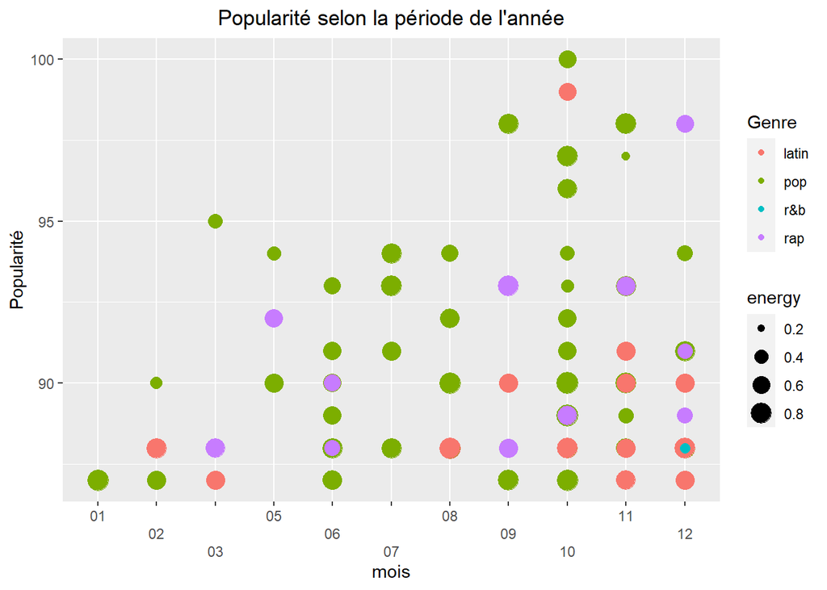

Les chansons les plus populaires sont celles sorties 3 mois avant la date des données. On observe que les tubes sortis en juin sont restées populaires.

# Section par Paolo Crosetto

## Questions additionnelles

### 1. Intervaux de confiance des corrélations

Ajoutez les intervaux de confiance de vos corrélations au plot de la question 7. Regardez le cours 6 pour des tutoriels à suivre.

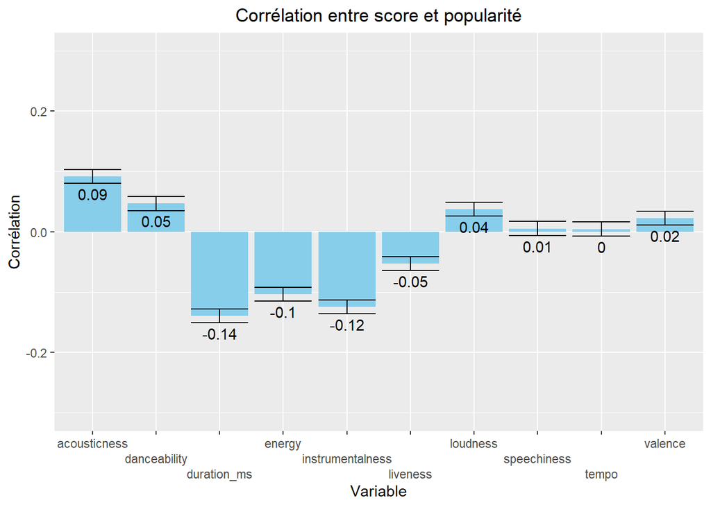

### 2. Extension de la question 8

Appliquez de façon compacte la même analyse faite pour EDM pour tous les genres. Montrez dans un plot compact (avec facet) vos résultats. Est-ce qu’il y a de la corrélation entre différents scores et popularité pour chacun des genres? (il y a différentes façons de faire ça, avec corr ou avec une régression linéaire… à vous de jouer)

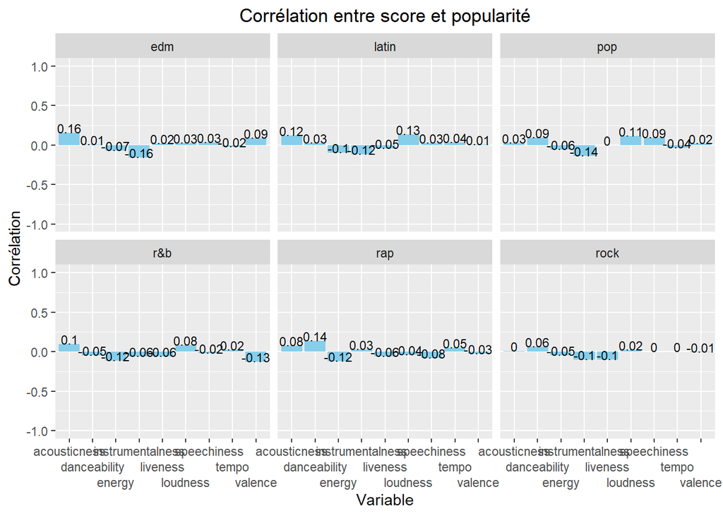

On constante que l’edm est celle qui a les corrélations les plus importantes avec 0.16 pour l’accoustique et -0.16 pour la presence ou non de voix. Le rap et la pop ont une corrélation avec la “danceabilité” supérieure à la moyenne (0.14 et 0.09 respectivement). La rnb est surprenamment négativement influencé par un ton de chanson positif (valence=-0.13). Le latin possède une corrélation élevée avec le bruit généré en décibels (loudness=0.13). Enfin, les variables sont peu efficace pour prédire si une chanson rock sera populaire ou non.

### 3. Moods saisonniers

Y a-t-il des moods saisonniers dans les chansons? Vous avez la date précise de sortie de la chanson/album, donc vous savez si la chanson est sortie à l’hiver, printemps, été… (on se limite aux saisons dans l’émisphère nord). Essayez d’utiliser les données sur energy/valence… et/ou le genre et de voir s’il y a des patterns saisonniers. Par exemple, est-ce que la musique latine apparaît comme par hasard au début de l’été comme j’ai l’impression ou c’est juste moi? Un plot qui pussie montrer clairement en un coup d’oeil s’il y a des trends saisonniers ou pas serait parfait.

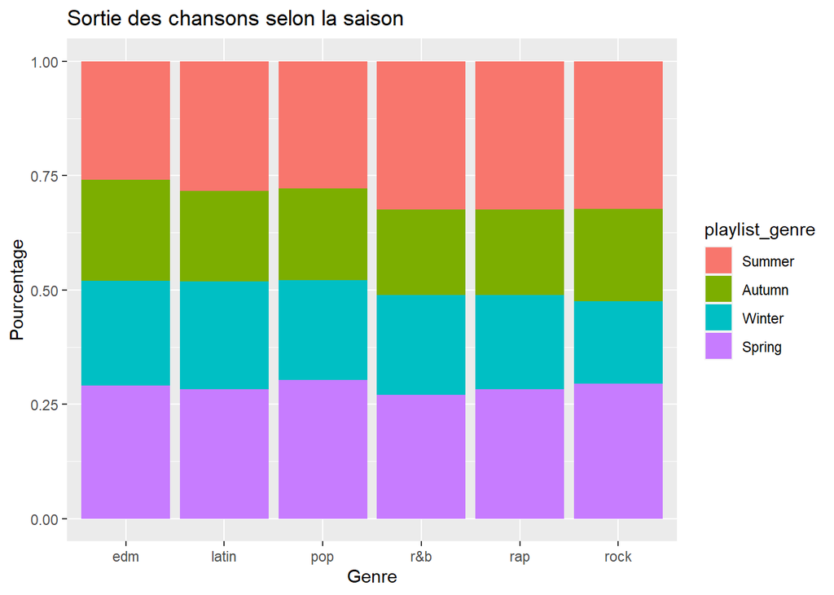